# When Marginal CRPS Misranks Trajectory Forecasts

Marginal, joint, and functional CRPS-family scoring rules on synthetic seasonal epidemic forecasts

Claude (Anthropic)

2026-05-12

## Motivation

Probabilistic forecasts of seasonal epidemics are typically evaluated by computing the Continuous Ranked Probability Score (CRPS) *marginally* at each forecast horizon and then averaging. (The Weighted Interval Score, WIS, used by CDC FluSight and the COVID-19 Forecast Hub, is a quantile approximation to this marginal CRPS.) Marginal scoring has a structural blind spot: a forecast that produces wide, well-centred marginal distributions at each horizon can score well even if it represents no coherent epidemic trajectory. Sharp forecasts that capture the shape of the wave but are slightly mistimed get heavily penalised at horizons near the peak.

This notebook submits forecasts as **sample trajectories** (hubverse `sample` output_type), which preserves the joint structure across horizons. With samples in hand we have no reason to use WIS; we can compute CRPS exactly. We then evaluate each forecaster under three CRPS-family scoring rules:

- **Marginal CRPS** — the baseline. Score the predictive distribution at each horizon independently, average across horizons. Sees marginal calibration only.
- **Joint multivariate CRPS generalisations** — the *energy score* and the *variogram score*. These score the predictive distribution as a single joint object over all 12 horizons. They see joint structure: whether the 12-dimensional samples actually look like plausible epidemic trajectories.
- **Functional CRPS** — derive a scalar quantity of operational interest from each sample trajectory (peak week, peak intensity, cumulative burden, time above threshold), then apply CRPS to that scalar. Sees decision-relevant quantities directly.

We construct seven caricature forecasters in three natural pairs plus a calibrated reference:

- **A** — wide hedger with i.i.d. samples across horizons (well-centred on truth, joint structure is white noise)
- **A′** — wide hedger with *coherent* trajectories around truth (similar marginal widths to A; differs only in joint structure)
- **B** — sharp forecaster with peak shifted ~2 weeks *late* (deterministic directional bias)
- **B′** — sharp forecaster with symmetric peak-time uncertainty: each sample peaks 0.5-3 weeks early *or* late, never on time, average correct
- **C** — sharp forecaster with correct timing but biased peak magnitude (~40% under-estimate)
- **C′** — wide hedger around C’s biased mean (same per-horizon mean as C, coherent multiplicative spread like A′)
- **D** — calibrated trajectory forecaster (reference baseline)

**Requirements.** Dev versions of `scoringutils` (≥ 2.1.2) and `hubEvals` (≥ 0.1.0). See the install chunk below; the same versions are used in `variogram-flusight-analysis/`.

```r
# Run once to install dev versions:
# remotes::install_github("epiforecasts/scoringutils")
# remotes::install_github("hubverse-org/hubEvals")
```

```r
library(dplyr)
library(tidyr)
library(tibble)
library(ggplot2)
library(patchwork)
library(scoringutils)
library(hubEvals)
```

## Ground truth

We use a skewed gamma-shaped seasonal wave on weeks 1–33 with peak near week 20. The choice of a *skewed* (not symmetric Gaussian) wave matters for forecaster B: a 2-week shift on a symmetric Gaussian leaves shape-aware metrics nearly unchanged, but on a skewed wave the post-peak decline differs from the pre-peak rise, so shape-aware metrics still penalise timing errors visibly.

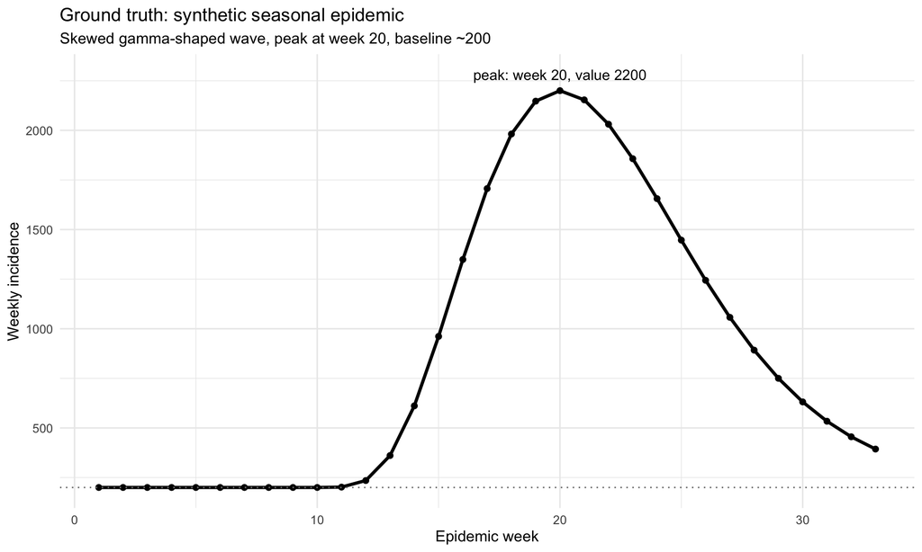

```r
set.seed(42)

WEEKS <- 1:33
BASELINE <- 200
PEAK_HEIGHT <- 2200
PEAK_WEEK <- 20
GAMMA_SHAPE <- 6
GAMMA_RATE <- 0.5

# Skewed gamma kernel, normalised so its maximum equals (peak_h - baseline)
# and shifted so its peak lands at peak_w.
gamma_kernel <- function(w, peak_w = PEAK_WEEK, peak_h = PEAK_HEIGHT,
                         baseline = BASELINE) {
  offset <- peak_w - (GAMMA_SHAPE - 1) / GAMMA_RATE
  k <- dgamma(w - offset, shape = GAMMA_SHAPE, rate = GAMMA_RATE)
  k_max <- dgamma((GAMMA_SHAPE - 1) / GAMMA_RATE,
                  shape = GAMMA_SHAPE, rate = GAMMA_RATE)
  baseline + (peak_h - baseline) * (k / k_max)
}

truth_fn <- function(w) gamma_kernel(w, peak_w = PEAK_WEEK, peak_h = PEAK_HEIGHT)
truth_vec <- truth_fn(WEEKS)

tibble(week = WEEKS, truth = truth_vec) |>
  ggplot(aes(x = week, y = truth)) +
  geom_line(linewidth = 1.2) +
  geom_point(size = 1.8) +
  geom_hline(yintercept = BASELINE, linetype = "dotted", colour = "grey50") +
  annotate("text", x = PEAK_WEEK, y = PEAK_HEIGHT + 80,
           label = sprintf("peak: week %d, value %d", PEAK_WEEK, PEAK_HEIGHT),
           hjust = 0.5, size = 4) +
  labs(title = "Ground truth: synthetic seasonal epidemic",
       subtitle = "Skewed gamma-shaped wave, peak at week 20, baseline ~200",
       x = "Epidemic week", y = "Weekly incidence") +
  theme_minimal(base_size = 12)
```

```r
ggsave("trajectory-scoring-comparison/plots/01_truth.png",
       width = 9, height = 5, dpi = 150)
```

## Forecast configuration

We issue forecasts from one reference date during the rising phase (epidemic week 14), looking ahead horizons -1 through 10 — i.e. target weeks 13 through 24, covering the rise, the peak, and the start of the decline. Each forecaster produces N = 500 sample trajectories.

```r
REF_WEEK <- 14
HORIZONS <- -1:10
TARGET_WEEKS <- REF_WEEK + HORIZONS
N_SAMPLES <- 500
N_HORIZONS <- length(HORIZONS)

# Week numbers map to Saturdays starting 2025-01-04 (a Saturday).
week_to_date <- function(w) as.Date("2025-01-04") + 7 * (w - 1)
REF_DATE <- week_to_date(REF_WEEK)
TARGET_DATES <- week_to_date(TARGET_WEEKS)
TRUTH_AT_TARGETS <- truth_fn(TARGET_WEEKS)
```

## The seven forecasters

Each forecaster’s output is a 500 × 12 matrix (samples × horizons). The function below packages such a matrix into hubverse `sample` output format: each row is one (sample, horizon) value, and the `output_type_id` ties the 12 horizons of one sample together into a coherent trajectory.

```r
make_sample_tbl <- function(model_id, sample_matrix) {
  stopifnot(dim(sample_matrix) == c(N_SAMPLES, N_HORIZONS))
  # as.vector goes column-major: (s1h1, s2h1, ..., sNh1, s1h2, ..., sNhH)
  tibble(
    model_id = model_id,
    reference_date = REF_DATE,
    horizon = rep(HORIZONS, each = N_SAMPLES),
    target_end_date = rep(TARGET_DATES, each = N_SAMPLES),
    target = "wk inc flu hosp",
    location = "US",
    output_type = "sample",
    output_type_id = as.character(rep(seq_len(N_SAMPLES),
                                      times = N_HORIZONS)),
    value = pmax(as.vector(sample_matrix), 0)
  )
}
```

### Forecaster A — wide hedger, i.i.d. across horizons

A forecaster who reports a wide marginal distribution at each horizon, well-centred on truth, with **uncertainty proportional to truth magnitude** (more uncertainty where the wave is large, less where it is small — the typical pattern for count-valued epi forecasts). Samples are independent across horizons, so each trajectory is a noisy path around truth with no temporal coherence.

```r
SIGMA_FRAC <- 0.5   # Marginal SD at horizon h is SIGMA_FRAC * truth[h]
sigma_per_horizon <- SIGMA_FRAC * TRUTH_AT_TARGETS

# Independent unit-variance noise per (horizon, sample); scaled per column by truth
noise_A <- matrix(rnorm(N_SAMPLES * N_HORIZONS, 0, 1),
                  nrow = N_SAMPLES, ncol = N_HORIZONS)
noise_A <- sweep(noise_A, 2, sigma_per_horizon, FUN = "*")
sample_A <- sweep(noise_A, 2, TRUTH_AT_TARGETS, FUN = "+")
forecast_A <- make_sample_tbl("A_hedger_iid", sample_A)
```

### Forecaster A′ — coherent trajectories with similar marginal widths to A

Each sample `i` gets a single shared **multiplicative amplitude factor** `m_i = 1 + c_i` with `c_i ~ Normal(0, SIGMA_FRAC^2)`. The trajectory is `truth[h] * m_i + small_noise[h]`, where `small_noise[h] ~ Normal(0, (0.05 * truth[h])^2)` adds the same kind of within-trajectory per-horizon noise that forecasters B, C, and D have. The marginal SD at horizon `h` is `sqrt(SIGMA_FRAC^2 + 0.05^2) * truth[h] ≈ SIGMA_FRAC * truth[h]` — essentially the same width as A.

The difference between A and A′ is joint structure. A′’s 500 samples are 500 amplitude-scaled copies of the true wave plus small per-horizon noise, so each trajectory peaks at the right week and traces the right shape — just with random amplitude. A’s 500 samples are 500 noisy paths with no shared structure. Marginal CRPS sees A and A′ as roughly equivalent; joint and functional scores see them as very different.

```r
# Shared per-sample multiplicative amplitude factor
A2_mult <- 1 + rnorm(N_SAMPLES, 0, SIGMA_FRAC)

# Mean trajectory per sample: amplitude-scaled truth
mean_A2 <- outer(A2_mult, TRUTH_AT_TARGETS)

# Per-horizon within-trajectory noise (matches B/C/D's noise scale)
within_noise_sd <- 0.05 * TRUTH_AT_TARGETS
within_noise <- sweep(
  matrix(rnorm(N_SAMPLES * N_HORIZONS, 0, 1),
         nrow = N_SAMPLES, ncol = N_HORIZONS),
  2, within_noise_sd, FUN = "*"
)
sample_A2 <- mean_A2 + within_noise
forecast_A2 <- make_sample_tbl("A_hedger_coherent", sample_A2)
```

### Forecaster B — sharp, correct shape, mistimed peak

Each sample’s trajectory is the truth function evaluated at *shifted* target weeks; the shift `delta_i` is drawn around +2 (peak comes ~2 weeks late). Sharp predictions placed at the wrong target value near the peak — exactly the regime where marginal CRPS punishes sharp-and-shifted forecasts.

```r
B_deltas <- rnorm(N_SAMPLES, mean = 2, sd = 0.5)
B_multipliers <- rnorm(N_SAMPLES, mean = 1, sd = 0.05)

sample_B <- matrix(NA_real_, nrow = N_SAMPLES, ncol = N_HORIZONS)
for (i in seq_len(N_SAMPLES)) {
  sample_B[i, ] <- B_multipliers[i] * truth_fn(TARGET_WEEKS - B_deltas[i]) +
    rnorm(N_HORIZONS, 0, 0.05 * TRUTH_AT_TARGETS)
}
forecast_B <- make_sample_tbl("B_sharp_mistimed", sample_B)
```

### Forecaster B′ — sharp, symmetric peak-timing uncertainty, correct peak height

A direct analogue of B, but with a peak-time shift that is *symmetric around zero* and *never exactly zero*. Each sample’s shift is drawn as `shift_i = sign_i * delta_i`, where `sign_i ∈ {-1, +1}` with equal probability and `delta_i ~ Uniform(0.5, 3)`. Half the samples peak early (target weeks 17-19.5), half peak late (target weeks 20.5-23); none peak at the correct week 20. The amplitude multiplier stays near 1 so the *height* of each shifted peak still matches truth.

```r
Bp_signs <- sample(c(-1, 1), N_SAMPLES, replace = TRUE)
Bp_delta_mags <- runif(N_SAMPLES, min = 0.5, max = 3)
Bp_shifts <- Bp_signs * Bp_delta_mags
Bp_multipliers <- rnorm(N_SAMPLES, mean = 1, sd = 0.05)

sample_Bprime <- matrix(NA_real_, nrow = N_SAMPLES, ncol = N_HORIZONS)
for (i in seq_len(N_SAMPLES)) {
  sample_Bprime[i, ] <- Bp_multipliers[i] * truth_fn(TARGET_WEEKS - Bp_shifts[i]) +
    rnorm(N_HORIZONS, 0, 0.05 * TRUTH_AT_TARGETS)
}
forecast_Bprime <- make_sample_tbl("Bp_symmetric_shift", sample_Bprime)
```

### Forecaster C — sharp, correct timing, biased magnitude

Each sample’s trajectory has the right peak week but a peak amplitude scaled down by ~40%. Baseline preserved; the deviation above baseline is compressed by `alpha_i ~ N(0.6, 0.05^2)`.

```r
C_alphas <- rnorm(N_SAMPLES, mean = 0.6, sd = 0.05)

sample_C <- matrix(NA_real_, nrow = N_SAMPLES, ncol = N_HORIZONS)
for (i in seq_len(N_SAMPLES)) {
  sample_C[i, ] <- BASELINE + C_alphas[i] * (TRUTH_AT_TARGETS - BASELINE) +
    rnorm(N_HORIZONS, 0, 0.05 * TRUTH_AT_TARGETS)
}
forecast_C <- make_sample_tbl("C_sharp_biased", sample_C)
```

### Forecaster C′ — wide hedger around the biased mean

A direct analogue of A′, but built around C’s biased mean trajectory instead of truth. Per-sample multiplicative amplitude factor `m_i = 1 + c_i` with `c_i ~ Normal(0, SIGMA_FRAC^2)` scales the *biased mean* trajectory `BASELINE + 0.6 * (truth - BASELINE)`, then small per-horizon noise is added. Marginal mean at each horizon matches C exactly; marginal width matches A′’s structural form (multiplicative coherent offset) but applied around the biased mean.

The point: C and C′ have the same biased mean at every horizon, so their *bias* signature is identical. They differ only in spread — C is sharp around the biased mean, C′ is wide around it. This isolates how sharpness interacts with bias: when a forecaster’s central estimate is wrong, does extra width help or hurt?

```r
C_compressed_truth <- BASELINE + 0.6 * (TRUTH_AT_TARGETS - BASELINE)

Cprime_mult <- 1 + rnorm(N_SAMPLES, 0, SIGMA_FRAC)
mean_Cprime <- outer(Cprime_mult, C_compressed_truth)

Cprime_within_noise <- sweep(
  matrix(rnorm(N_SAMPLES * N_HORIZONS, 0, 1),
         nrow = N_SAMPLES, ncol = N_HORIZONS),
  2, 0.05 * TRUTH_AT_TARGETS, FUN = "*"
)
sample_Cprime <- mean_Cprime + Cprime_within_noise
forecast_Cprime <- make_sample_tbl("Cp_wide_biased", sample_Cprime)
```

### Forecaster D — calibrated trajectory

The reference baseline: per-sample multiplicative jitter `eta_i ~ N(1, 0.05^2)` plus small additive noise. Roughly right on shape, timing, and magnitude.

```r
D_etas <- rnorm(N_SAMPLES, mean = 1, sd = 0.05)

sample_D <- matrix(NA_real_, nrow = N_SAMPLES, ncol = N_HORIZONS)
for (i in seq_len(N_SAMPLES)) {
  sample_D[i, ] <- D_etas[i] * TRUTH_AT_TARGETS +
    rnorm(N_HORIZONS, 0, 0.05 * TRUTH_AT_TARGETS)
}
forecast_D <- make_sample_tbl("D_calibrated", sample_D)
```

### Combine into a single hubverse model_out_tbl

```r
all_samples <- bind_rows(forecast_A, forecast_A2,
                         forecast_B, forecast_Bprime,
                         forecast_C, forecast_Cprime,
                         forecast_D)

# Oracle (truth) in hubEvals format
oracle <- tibble(
  location = "US",
  target_end_date = TARGET_DATES,
  target = "wk inc flu hosp",
  oracle_value = TRUTH_AT_TARGETS
)

MODEL_LEVELS <- c("A_hedger_iid", "A_hedger_coherent",
                  "B_sharp_mistimed", "Bp_symmetric_shift",
                  "C_sharp_biased",   "Cp_wide_biased",
                  "D_calibrated")
MODEL_LABELS <- c(
  A_hedger_iid       = "A: Wide hedger\n(i.i.d. across horizons)",
  A_hedger_coherent  = "A': Wide hedger\n(coherent trajectories)",
  B_sharp_mistimed   = "B: Sharp,\nmistimed peak (late)",
  Bp_symmetric_shift = "B': Sharp,\nsymmetric peak-time error",
  C_sharp_biased     = "C: Sharp,\nbiased magnitude",
  Cp_wide_biased     = "C': Wide hedger\naround biased mean",
  D_calibrated       = "D: Calibrated\ntrajectory"
)
```

## Visualise the seven forecasters

The single most important plot in this analysis. Same truth in black across all seven panels, with 80 sample trajectories per forecaster shown in faint blue. Pairs (A/A′, B/B′, C/C′) are stacked in adjacent columns so each pair is easy to compare directly. The vertical dashed line in each panel marks the reference date; everything to its right is forecast territory.

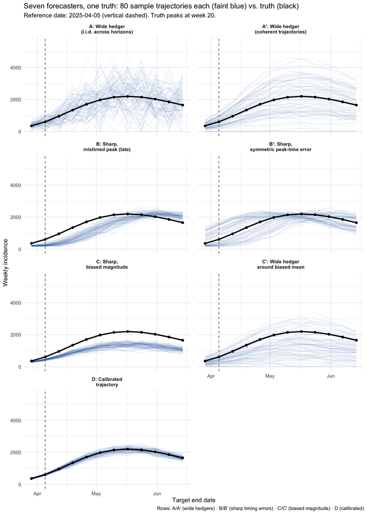

```r
set.seed(123)
display_sample_ids <- as.character(sample(seq_len(N_SAMPLES), 80))

display_samples <- all_samples |>
  filter(output_type_id %in% display_sample_ids) |>
  mutate(model_id = factor(model_id, levels = MODEL_LEVELS))

truth_df <- tibble(
  target_end_date = TARGET_DATES,
  value = TRUTH_AT_TARGETS
)

y_max <- max(all_samples$value, TRUTH_AT_TARGETS) * 1.02

p_traj <- ggplot(display_samples,
                 aes(x = target_end_date, y = value)) +
  geom_line(aes(group = output_type_id),
            alpha = 0.08, colour = "#2166AC") +
  geom_line(data = truth_df, colour = "black", linewidth = 1.2) +
  geom_point(data = truth_df, colour = "black", size = 1.8) +
  geom_vline(xintercept = as.numeric(REF_DATE),
             linetype = "dashed", colour = "grey40") +
  facet_wrap(~model_id, ncol = 2,
             labeller = labeller(model_id = MODEL_LABELS)) +
  coord_cartesian(ylim = c(0, y_max)) +
  labs(
    title = "Seven forecasters, one truth: 80 sample trajectories each (faint blue) vs. truth (black)",
    caption = "Rows: A/A' (wide hedgers) · B/B' (sharp timing errors) · C/C' (biased magnitude) · D (calibrated)",
    subtitle = sprintf("Reference date: %s (vertical dashed). Truth peaks at week %d.",
                       REF_DATE, PEAK_WEEK),
    x = "Target end date", y = "Weekly incidence"
  ) +
  theme_minimal(base_size = 12) +
  theme(
    strip.text = element_text(face = "bold"),
    panel.spacing.x = unit(1, "lines")
  )

p_traj
```

```r
ggsave("trajectory-scoring-comparison/plots/02_forecaster_trajectories.png",
       p_traj, width = 10, height = 14, dpi = 150)
```

## Marginal CRPS

Since we have samples, we can compute CRPS exactly — no need to summarise to quantiles first. `hubEvals::score_model_out` accepts hubverse sample forecasts directly and computes marginal CRPS per task.

```r
marginal_crps <- score_model_out(
  all_samples, oracle,
  metrics = "crps",
  summarize = FALSE
)

crps_by_horizon <- marginal_crps |>
  group_by(model_id, horizon) |>
  summarise(crps = mean(crps), .groups = "drop")

crps_by_model <- marginal_crps |>
  group_by(model_id) |>
  summarise(crps = mean(crps), .groups = "drop") |>
  arrange(crps)

crps_by_model |>
  mutate(crps = round(crps, 1)) |>
  knitr::kable(col.names = c("Model", "Mean marginal CRPS"),
               caption = "Marginal CRPS ranking (lower is better)")
```

Marginal CRPS ranking (lower is better)

| Model | Mean marginal CRPS |
| --- | --- |
| D_calibrated | 25.2 |
| Bp_symmetric_shift | 147.4 |
| A_hedger_coherent | 182.1 |
| A_hedger_iid | 187.9 |
| B_sharp_mistimed | 322.2 |
| Cp_wide_biased | 354.1 |
| C_sharp_biased | 492.7 |

A and A′ should be effectively tied here — their marginal distributions at each horizon are identical by construction (both `Normal(truth[h], sigma_wide^2)`), so marginal CRPS cannot tell them apart. Any difference between them in this table is sampling noise from the 500 draws.

## Marginal CRPS by horizon

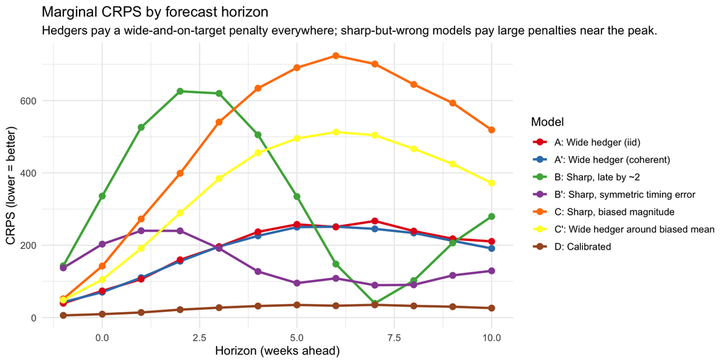

```r
p_crps_h <- crps_by_horizon |>
  mutate(model_id = factor(model_id, levels = MODEL_LEVELS)) |>
  ggplot(aes(x = horizon, y = crps, colour = model_id)) +
  geom_line(linewidth = 1.1) +
  geom_point(size = 2.5) +
  scale_colour_brewer(
    palette = "Set1",
    labels = c(
      A_hedger_iid       = "A: Wide hedger (iid)",
      A_hedger_coherent  = "A': Wide hedger (coherent)",
      B_sharp_mistimed   = "B: Sharp, late by ~2",
      Bp_symmetric_shift = "B': Sharp, symmetric timing error",
      C_sharp_biased     = "C: Sharp, biased magnitude",
      Cp_wide_biased     = "C': Wide hedger around biased mean",
      D_calibrated       = "D: Calibrated"
    )
  ) +
  labs(
    title = "Marginal CRPS by forecast horizon",
    subtitle = "Hedgers pay a wide-and-on-target penalty everywhere; sharp-but-wrong models pay large penalties near the peak.",
    x = "Horizon (weeks ahead)", y = "CRPS (lower = better)",
    colour = "Model"
  ) +
  theme_minimal(base_size = 12) +
  theme(legend.position = "right")

p_crps_h
```

```r
ggsave("trajectory-scoring-comparison/plots/04_crps_by_horizon.png",
       p_crps_h, width = 11, height = 5, dpi = 150)
```

## Joint multivariate scoring: energy + variogram

For joint scoring we treat each forecast as a *multivariate* prediction over the 12 horizons. Each sample contributes one 12-dimensional vector. The energy score measures distance from the joint distribution to the truth vector; the variogram score (Scheuerer & Hamill 2015) measures whether the *pairwise differences* across horizons match the truth’s pairwise differences — directly targeting trajectory shape.

We build a multivariate-sample forecast object with `joint_across = "horizon"` so that horizon becomes the dimension over which the multivariate score is computed. The exact `scoringutils` API for sample multivariate forecasts may shift between versions; if `as_forecast_multivariate_sample` is not available, the fallback is to construct the score directly via `energy_score_multivariate()` and `variogram_score_multivariate()` on a (samples × horizons) matrix per task.

```r
mvs_data <- all_samples |>
  left_join(
    oracle |> rename(observed = oracle_value),
    by = c("location", "target_end_date", "target")
  ) |>
  mutate(
    reference_date = as.character(reference_date),
    target_end_date = as.character(target_end_date)
  )

# Try the high-level scoringutils API.
mvs_forecast <- as_forecast_multivariate_sample(
  mvs_data,
  forecast_unit = c("model_id", "reference_date", "horizon", "location"),
  joint_across = "horizon",
  observed = "observed",
  predicted = "value",
  sample_id = "output_type_id"
)

joint_scores_raw <- score(mvs_forecast)

joint_scores <- joint_scores_raw |>
  as.data.frame() |>
  select(model_id, energy_score, variogram_score)

joint_scores |>
  mutate(across(where(is.numeric), ~ round(.x, 1))) |>
  knitr::kable(col.names = c("Model", "Energy score", "Variogram score"),
               caption = "Joint multivariate scores (lower is better). Variogram is the default p (= 0.5 in current scoringutils).")
```

Joint multivariate scores (lower is better). Variogram is the default p (= 0.5 in current scoringutils).

| Model | Energy score | Variogram score |
| --- | --- | --- |
| A_hedger_iid | 840.9 | 17413.6 |
| A_hedger_coherent | 682.3 | 305.2 |
| B_sharp_mistimed | 1261.1 | 12568.7 |
| Bp_symmetric_shift | 586.4 | 5783.8 |
| C_sharp_biased | 1842.7 | 5110.1 |
| Cp_wide_biased | 1340.0 | 6524.9 |
| D_calibrated | 110.8 | 208.3 |

If the `as_forecast_multivariate_sample` call above fails on a given install (e.g., an older scoringutils version), the helper below computes the same two scores directly from each model’s (samples × horizons) matrix:

```r
compute_joint_scores_manual <- function(samples_mat, truth_vec, p = 0.5) {
  list(
    energy = scoringutils::energy_score_multivariate(
      observed = truth_vec,
      predicted = samples_mat
    ),
    variogram = scoringutils::variogram_score_multivariate(
      observed = truth_vec,
      predicted = samples_mat,
      p = p
    )
  )
}

# joint_scores_manual <- tibble(
#   model_id = MODEL_LEVELS,
#   scores = list(
#     compute_joint_scores_manual(sample_A,  TRUTH_AT_TARGETS),
#     compute_joint_scores_manual(sample_A2, TRUTH_AT_TARGETS),
#     compute_joint_scores_manual(sample_B,  TRUTH_AT_TARGETS),
#     compute_joint_scores_manual(sample_C,  TRUTH_AT_TARGETS),
#     compute_joint_scores_manual(sample_D,  TRUTH_AT_TARGETS)
#   )
# )
```

## CRPS on derived functionals

For each (model, sample) we compute four scalar functionals of the trajectory:

- **peak week** — `argmax` over target weeks
- **peak intensity** — `max` of the trajectory
- **cumulative burden** — sum over the 12 horizons
- **time above threshold** — number of weeks the trajectory exceeds half the truth’s windowed peak

Each scalar has a predictive distribution given by the 500 per-sample values. We score it against the truth value of the same functional using `crps_sample()`. These are proper scoring rules on the functional, and they directly encode the operational quantities public health agencies actually care about.

```r
get_sample_matrix <- function(forecast_long) {
  forecast_long |>
    arrange(as.integer(output_type_id), horizon) |>
    select(output_type_id, horizon, value) |>
    pivot_wider(names_from = horizon, values_from = value,
                names_sort = TRUE) |>
    select(-output_type_id) |>
    as.matrix()
}

THRESHOLD <- 0.5 * max(TRUTH_AT_TARGETS)

compute_functionals <- function(forecast_long) {
  mat <- get_sample_matrix(forecast_long)
  tibble(
    sample_id          = seq_len(nrow(mat)),
    peak_week          = TARGET_WEEKS[apply(mat, 1, which.max)],
    peak_intensity     = apply(mat, 1, max),
    cumulative_burden  = rowSums(mat),
    time_above_thresh  = rowSums(mat > THRESHOLD)
  )
}

functionals <- all_samples |>
  group_by(model_id) |>
  group_modify(~ compute_functionals(.x)) |>
  ungroup()

truth_functionals <- list(
  peak_week         = TARGET_WEEKS[which.max(TRUTH_AT_TARGETS)],
  peak_intensity    = max(TRUTH_AT_TARGETS),
  cumulative_burden = sum(TRUTH_AT_TARGETS),
  time_above_thresh = sum(TRUTH_AT_TARGETS > THRESHOLD)
)
truth_functionals
```

```
## $peak_week
## [1] 20
##
## $peak_intensity
## [1] 2200
##
## $cumulative_burden
## [1] 19015
##
## $time_above_thresh
## [1] 9
```

```r
crps_functionals <- functionals |>
  group_by(model_id) |>
  summarise(
    crps_peak_week = scoringutils::crps_sample(
      observed = truth_functionals$peak_week,
      predicted = matrix(peak_week, nrow = 1)
    ),
    crps_peak_intensity = scoringutils::crps_sample(
      observed = truth_functionals$peak_intensity,
      predicted = matrix(peak_intensity, nrow = 1)
    ),
    crps_cumulative = scoringutils::crps_sample(
      observed = truth_functionals$cumulative_burden,
      predicted = matrix(cumulative_burden, nrow = 1)
    ),
    crps_time_above = scoringutils::crps_sample(
      observed = truth_functionals$time_above_thresh,
      predicted = matrix(time_above_thresh, nrow = 1)
    ),
    .groups = "drop"
  )

crps_functionals |>
  mutate(across(where(is.numeric), ~ round(.x, 2))) |>
  knitr::kable(caption = "CRPS on derived trajectory functionals (lower is better)")
```

CRPS on derived trajectory functionals (lower is better)

| model_id | crps_peak_week | crps_peak_intensity | crps_cumulative | crps_time_above |
| --- | --- | --- | --- | --- |
| A_hedger_coherent | 0.15 | 254.44 | 2172.90 | 0.55 |
| A_hedger_iid | 0.47 | 902.57 | 699.15 | 0.92 |
| B_sharp_mistimed | 1.47 | 39.48 | 2418.69 | 1.54 |
| Bp_symmetric_shift | 0.60 | 45.81 | 723.70 | 0.67 |
| C_sharp_biased | 0.24 | 652.17 | 6123.75 | 1.83 |
| Cp_wide_biased | 0.24 | 451.35 | 4237.16 | 1.96 |
| D_calibrated | 0.16 | 39.90 | 209.91 | 0.00 |